# 20251113 course project

Jiayu

2025-11-13

```r
library(caret)
library(tidyverse)
library(skimr)
library(pdp)
library(patchwork)
```

#2. import the datasets, fill in NAs

```r
training <- read.csv("./pml-training.csv", na = c("", " ", "NA", "N/A", "NULL"))
testing <- read.csv("./pml-testing.csv", na = c("", " ", "NA", "N/A", "NULL"))
```

#3. understand the training data: get a basic idea with summary(); check missing values with is.na().

```r
summary(training)
```

```
##        X          user_name         raw_timestamp_part_1 raw_timestamp_part_2
##  Min.   :    1   Length:19622       Min.   :1.322e+09    Min.   :   294
##  1st Qu.: 4906   Class :character   1st Qu.:1.323e+09    1st Qu.:252912
##  Median : 9812   Mode  :character   Median :1.323e+09    Median :496380
##  Mean   : 9812                      Mean   :1.323e+09    Mean   :500656
##  3rd Qu.:14717                      3rd Qu.:1.323e+09    3rd Qu.:751891
##  Max.   :19622                      Max.   :1.323e+09    Max.   :998801
##
##  cvtd_timestamp      new_window          num_window      roll_belt
##  Length:19622       Length:19622       Min.   :  1.0   Min.   :-28.90
##  Class :character   Class :character   1st Qu.:222.0   1st Qu.:  1.10
##  Mode  :character   Mode  :character   Median :424.0   Median :113.00
##                                        Mean   :430.6   Mean   : 64.41
##                                        3rd Qu.:644.0   3rd Qu.:123.00
##                                        Max.   :864.0   Max.   :162.00
##
##    pitch_belt          yaw_belt       total_accel_belt kurtosis_roll_belt
##  Min.   :-55.8000   Min.   :-180.00   Min.   : 0.00    Length:19622
##  1st Qu.:  1.7600   1st Qu.: -88.30   1st Qu.: 3.00    Class :character
##  Median :  5.2800   Median : -13.00   Median :17.00    Mode  :character
##  Mean   :  0.3053   Mean   : -11.21   Mean   :11.31
##  3rd Qu.: 14.9000   3rd Qu.:  12.90   3rd Qu.:18.00
##  Max.   : 60.3000   Max.   : 179.00   Max.   :29.00
##
##  kurtosis_picth_belt kurtosis_yaw_belt  skewness_roll_belt skewness_roll_belt.1
##  Length:19622        Length:19622       Length:19622       Length:19622
##  Class :character    Class :character   Class :character   Class :character
##  Mode  :character    Mode  :character   Mode  :character   Mode  :character
##
##
##
##
##  skewness_yaw_belt  max_roll_belt     max_picth_belt  max_yaw_belt
##  Length:19622       Min.   :-94.300   Min.   : 3.00   Length:19622
##  Class :character   1st Qu.:-88.000   1st Qu.: 5.00   Class :character
##  Mode  :character   Median : -5.100   Median :18.00   Mode  :character
##                     Mean   : -6.667   Mean   :12.92
##                     3rd Qu.: 18.500   3rd Qu.:19.00
##                     Max.   :180.000   Max.   :30.00
##                     NA's   :19216     NA's   :19216
```

[output cut: 289 more lines]

```
##  Min.   :-446.00   Min.   :-1280.0   Min.   :-896.0   Min.   :-973.0
##  1st Qu.:-182.00   1st Qu.: -616.0   1st Qu.:   2.0   1st Qu.: 191.0
##  Median : -39.00   Median : -378.0   Median : 591.0   Median : 511.0
##  Mean   : -55.29   Mean   : -312.6   Mean   : 380.1   Mean   : 393.6
##  3rd Qu.:  26.00   3rd Qu.:  -73.0   3rd Qu.: 737.0   3rd Qu.: 653.0
##  Max.   : 291.00   Max.   :  672.0   Max.   :1480.0   Max.   :1090.0
##
##     classe
##  Length:19622
##  Class :character
##  Mode  :character
##
##
##
##
```

```r
colMeans(is.na(training)) |>
  round(3) |>
  sort(decreasing = TRUE)
```

```
##       kurtosis_roll_belt      kurtosis_picth_belt        kurtosis_yaw_belt
##                    0.979                    0.979                    0.979
##       skewness_roll_belt     skewness_roll_belt.1        skewness_yaw_belt
##                    0.979                    0.979                    0.979
##            max_roll_belt           max_picth_belt             max_yaw_belt
##                    0.979                    0.979                    0.979
##            min_roll_belt           min_pitch_belt             min_yaw_belt
##                    0.979                    0.979                    0.979
##      amplitude_roll_belt     amplitude_pitch_belt       amplitude_yaw_belt
##                    0.979                    0.979                    0.979
##     var_total_accel_belt            avg_roll_belt         stddev_roll_belt
##                    0.979                    0.979                    0.979
##            var_roll_belt           avg_pitch_belt        stddev_pitch_belt
##                    0.979                    0.979                    0.979
##           var_pitch_belt             avg_yaw_belt          stddev_yaw_belt
##                    0.979                    0.979                    0.979
##             var_yaw_belt            var_accel_arm             avg_roll_arm
##                    0.979                    0.979                    0.979
##          stddev_roll_arm             var_roll_arm            avg_pitch_arm
##                    0.979                    0.979                    0.979
##         stddev_pitch_arm            var_pitch_arm              avg_yaw_arm
##                    0.979                    0.979                    0.979
##           stddev_yaw_arm              var_yaw_arm        kurtosis_roll_arm
##                    0.979                    0.979                    0.979
##       kurtosis_picth_arm         kurtosis_yaw_arm        skewness_roll_arm
##                    0.979                    0.979                    0.979
##       skewness_pitch_arm         skewness_yaw_arm             max_roll_arm
##                    0.979                    0.979                    0.979
##            max_picth_arm              max_yaw_arm             min_roll_arm
##                    0.979                    0.979                    0.979
##            min_pitch_arm              min_yaw_arm       amplitude_roll_arm
##                    0.979                    0.979                    0.979
##      amplitude_pitch_arm        amplitude_yaw_arm   kurtosis_roll_dumbbell
##                    0.979                    0.979                    0.979
##  kurtosis_picth_dumbbell    kurtosis_yaw_dumbbell   skewness_roll_dumbbell
##                    0.979                    0.979                    0.979
##  skewness_pitch_dumbbell    skewness_yaw_dumbbell        max_roll_dumbbell
##                    0.979                    0.979                    0.979
##       max_picth_dumbbell         max_yaw_dumbbell        min_roll_dumbbell
##                    0.979                    0.979                    0.979
```

[output cut: 53 more lines]

```
##                    0.000                    0.000                    0.000
##         accel_dumbbell_y         accel_dumbbell_z        magnet_dumbbell_x
##                    0.000                    0.000                    0.000
##        magnet_dumbbell_y        magnet_dumbbell_z             roll_forearm
##                    0.000                    0.000                    0.000
##            pitch_forearm              yaw_forearm      total_accel_forearm
##                    0.000                    0.000                    0.000
##          gyros_forearm_x          gyros_forearm_y          gyros_forearm_z
##                    0.000                    0.000                    0.000
##          accel_forearm_x          accel_forearm_y          accel_forearm_z
##                    0.000                    0.000                    0.000
##         magnet_forearm_x         magnet_forearm_y         magnet_forearm_z
##                    0.000                    0.000                    0.000
##                   classe
##                    0.000
```

#4. data preprocessing: remove columns with over 95% missing values and rows that are non-predictive; check near zero variance columns; check collinearity; check class balance; check overall data distribution

```r
training <- training[,colMeans(is.na(training)) < 0.95] |>
  select(-c(X, user_name, raw_timestamp_part_1, raw_timestamp_part_2, cvtd_timestamp, new_window, num_window))

dim(training)
```

```
## [1] 19622    53
```

```r
sum(is.na(training))
```

```
## [1] 0
```

```r
nzv <- nearZeroVar(training)
nzv
```

```
## integer(0)
```

```r
training_numeric <- training |>
  select(where(is.numeric))

cor_matrix <- cor(training_numeric)
findCorrelation(cor_matrix, cutoff=0.9)
```

```
## [1] 10  1  9  8 31 33 18
```

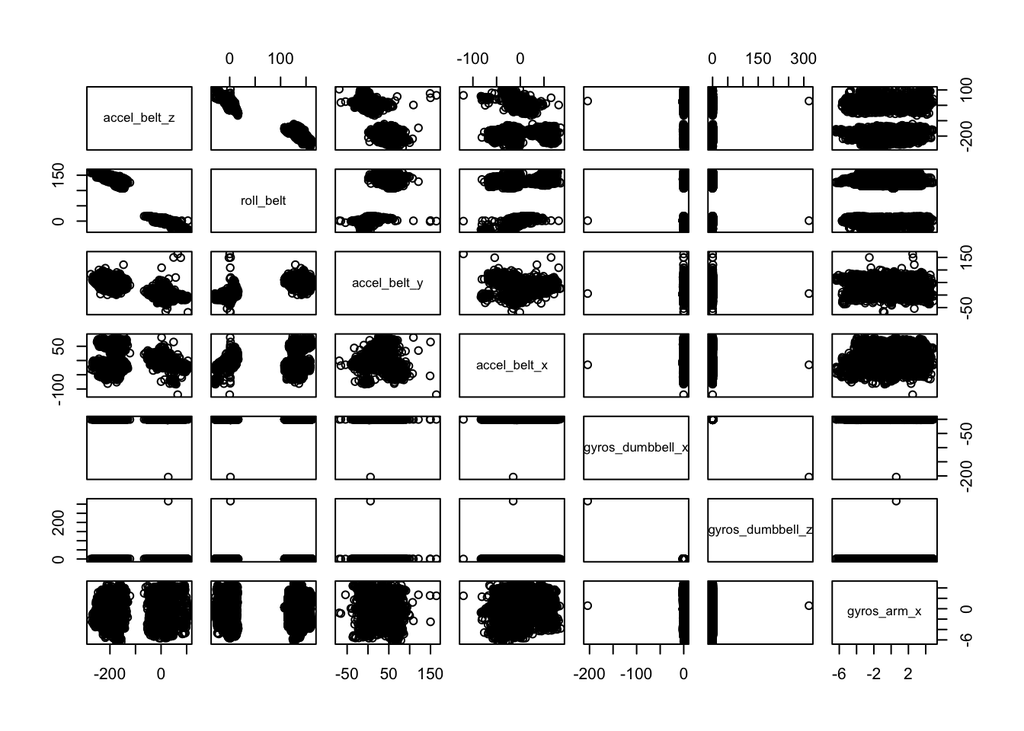

```r
pairs(training_numeric[,c(10,1,9,8,31,33,18)])
```

```r
table(training$classe)
```

```
##
##    A    B    C    D    E
## 5580 3797 3422 3216 3607
```

```r
skim(training)
```

Data summary

| Name | training |
| --- | --- |
| Number of rows | 19622 |
| Number of columns | 53 |
| _______________________ |  |
| Column type frequency: |  |
| character | 1 |
| numeric | 52 |
| ________________________ |  |
| Group variables | None |

**Variable type: character**

| skim_variable | n_missing | complete_rate | min | max | empty | n_unique | whitespace |
| --- | --- | --- | --- | --- | --- | --- | --- |
| classe | 0 | 1 | 1 | 1 | 0 | 5 | 0 |

**Variable type: numeric**

| skim_variable | n_missing | complete_rate | mean | sd | p0 | p25 | p50 | p75 | p100 | hist |
| --- | --- | --- | --- | --- | --- | --- | --- | --- | --- | --- |
| roll_belt | 0 | 1 | 64.41 | 62.75 | -28.90 | 1.10 | 113.00 | 123.00 | 162.00 | ▇▁▁▅▅ |
| pitch_belt | 0 | 1 | 0.31 | 22.35 | -55.80 | 1.76 | 5.28 | 14.90 | 60.30 | ▃▁▇▅▁ |
| yaw_belt | 0 | 1 | -11.21 | 95.19 | -180.00 | -88.30 | -13.00 | 12.90 | 179.00 | ▁▇▅▁▃ |
| total_accel_belt | 0 | 1 | 11.31 | 7.74 | 0.00 | 3.00 | 17.00 | 18.00 | 29.00 | ▇▁▂▆▁ |
| gyros_belt_x | 0 | 1 | -0.01 | 0.21 | -1.04 | -0.03 | 0.03 | 0.11 | 2.22 | ▁▇▁▁▁ |
| gyros_belt_y | 0 | 1 | 0.04 | 0.08 | -0.64 | 0.00 | 0.02 | 0.11 | 0.64 | ▁▁▇▁▁ |
| gyros_belt_z | 0 | 1 | -0.13 | 0.24 | -1.46 | -0.20 | -0.10 | -0.02 | 1.62 | ▁▂▇▁▁ |
| accel_belt_x | 0 | 1 | -5.59 | 29.64 | -120.00 | -21.00 | -15.00 | -5.00 | 85.00 | ▁▁▇▁▂ |
| accel_belt_y | 0 | 1 | 30.15 | 28.58 | -69.00 | 3.00 | 35.00 | 61.00 | 164.00 | ▁▇▇▁▁ |
| accel_belt_z | 0 | 1 | -72.59 | 100.45 | -275.00 | -162.00 | -152.00 | 27.00 | 105.00 | ▁▇▁▅▃ |
| magnet_belt_x | 0 | 1 | 55.60 | 64.18 | -52.00 | 9.00 | 35.00 | 59.00 | 485.00 | ▇▁▂▁▁ |
| magnet_belt_y | 0 | 1 | 593.68 | 35.68 | 354.00 | 581.00 | 601.00 | 610.00 | 673.00 | ▁▁▁▇▃ |
| magnet_belt_z | 0 | 1 | -345.48 | 65.21 | -623.00 | -375.00 | -320.00 | -306.00 | 293.00 | ▁▇▁▁▁ |
| roll_arm | 0 | 1 | 17.83 | 72.74 | -180.00 | -31.78 | 0.00 | 77.30 | 180.00 | ▁▃▇▆▂ |
| pitch_arm | 0 | 1 | -4.61 | 30.68 | -88.80 | -25.90 | 0.00 | 11.20 | 88.50 | ▁▅▇▂▁ |
| yaw_arm | 0 | 1 | -0.62 | 71.36 | -180.00 | -43.10 | 0.00 | 45.88 | 180.00 | ▁▃▇▃▂ |
| total_accel_arm | 0 | 1 | 25.51 | 10.52 | 1.00 | 17.00 | 27.00 | 33.00 | 66.00 | ▃▆▇▁▁ |
| gyros_arm_x | 0 | 1 | 0.04 | 1.99 | -6.37 | -1.33 | 0.08 | 1.57 | 4.87 | ▁▃▇▆▂ |
| gyros_arm_y | 0 | 1 | -0.26 | 0.85 | -3.44 | -0.80 | -0.24 | 0.14 | 2.84 | ▁▂▇▂▁ |
| gyros_arm_z | 0 | 1 | 0.27 | 0.55 | -2.33 | -0.07 | 0.23 | 0.72 | 3.02 | ▁▂▇▂▁ |
| accel_arm_x | 0 | 1 | -60.24 | 182.04 | -404.00 | -242.00 | -44.00 | 84.00 | 437.00 | ▇▅▇▅▁ |
| accel_arm_y | 0 | 1 | 32.60 | 109.87 | -318.00 | -54.00 | 14.00 | 139.00 | 308.00 | ▁▃▇▆▂ |
| accel_arm_z | 0 | 1 | -71.25 | 134.65 | -636.00 | -143.00 | -47.00 | 23.00 | 292.00 | ▁▁▅▇▁ |
| magnet_arm_x | 0 | 1 | 191.72 | 443.64 | -584.00 | -300.00 | 289.00 | 637.00 | 782.00 | ▆▃▂▃▇ |
| magnet_arm_y | 0 | 1 | 156.61 | 201.91 | -392.00 | -9.00 | 202.00 | 323.00 | 583.00 | ▁▅▅▇▂ |
| magnet_arm_z | 0 | 1 | 306.49 | 326.62 | -597.00 | 131.25 | 444.00 | 545.00 | 694.00 | ▁▂▂▃▇ |
| roll_dumbbell | 0 | 1 | 23.84 | 69.93 | -153.71 | -18.49 | 48.17 | 67.61 | 153.55 | ▂▂▃▇▂ |
| pitch_dumbbell | 0 | 1 | -10.78 | 36.99 | -149.59 | -40.89 | -20.96 | 17.50 | 149.40 | ▁▆▇▂▁ |
| yaw_dumbbell | 0 | 1 | 1.67 | 82.52 | -150.87 | -77.64 | -3.32 | 79.64 | 154.95 | ▃▇▅▅▆ |
| total_accel_dumbbell | 0 | 1 | 13.72 | 10.23 | 0.00 | 4.00 | 10.00 | 19.00 | 58.00 | ▇▅▃▁▁ |
| gyros_dumbbell_x | 0 | 1 | 0.16 | 1.51 | -204.00 | -0.03 | 0.13 | 0.35 | 2.22 | ▁▁▁▁▇ |
| gyros_dumbbell_y | 0 | 1 | 0.05 | 0.61 | -2.10 | -0.14 | 0.03 | 0.21 | 52.00 | ▇▁▁▁▁ |
| gyros_dumbbell_z | 0 | 1 | -0.13 | 2.29 | -2.38 | -0.31 | -0.13 | 0.03 | 317.00 | ▇▁▁▁▁ |
| accel_dumbbell_x | 0 | 1 | -28.62 | 67.32 | -419.00 | -50.00 | -8.00 | 11.00 | 235.00 | ▁▁▆▇▁ |
| accel_dumbbell_y | 0 | 1 | 52.63 | 80.75 | -189.00 | -8.00 | 41.50 | 111.00 | 315.00 | ▁▇▇▅▁ |
| accel_dumbbell_z | 0 | 1 | -38.32 | 109.47 | -334.00 | -142.00 | -1.00 | 38.00 | 318.00 | ▁▆▇▃▁ |
| magnet_dumbbell_x | 0 | 1 | -328.48 | 339.72 | -643.00 | -535.00 | -479.00 | -304.00 | 592.00 | ▇▂▁▁▂ |
| magnet_dumbbell_y | 0 | 1 | 220.97 | 326.87 | -3600.00 | 231.00 | 311.00 | 390.00 | 633.00 | ▁▁▁▁▇ |
| magnet_dumbbell_z | 0 | 1 | 46.05 | 139.96 | -262.00 | -45.00 | 13.00 | 95.00 | 452.00 | ▁▇▆▂▂ |
| roll_forearm | 0 | 1 | 33.83 | 108.04 | -180.00 | -0.74 | 21.70 | 140.00 | 180.00 | ▃▂▇▂▇ |
| pitch_forearm | 0 | 1 | 10.71 | 28.15 | -72.50 | 0.00 | 9.24 | 28.40 | 89.80 | ▁▁▇▃▁ |
| yaw_forearm | 0 | 1 | 19.21 | 103.22 | -180.00 | -68.60 | 0.00 | 110.00 | 180.00 | ▅▅▇▆▇ |
| total_accel_forearm | 0 | 1 | 34.72 | 10.06 | 0.00 | 29.00 | 36.00 | 41.00 | 108.00 | ▁▇▂▁▁ |
| gyros_forearm_x | 0 | 1 | 0.16 | 0.65 | -22.00 | -0.22 | 0.05 | 0.56 | 3.97 | ▁▁▁▁▇ |
| gyros_forearm_y | 0 | 1 | 0.08 | 3.10 | -7.02 | -1.46 | 0.03 | 1.62 | 311.00 | ▇▁▁▁▁ |
| gyros_forearm_z | 0 | 1 | 0.15 | 1.75 | -8.09 | -0.18 | 0.08 | 0.49 | 231.00 | ▇▁▁▁▁ |
| accel_forearm_x | 0 | 1 | -61.65 | 180.59 | -498.00 | -178.00 | -57.00 | 76.00 | 477.00 | ▂▆▇▅▁ |
| accel_forearm_y | 0 | 1 | 163.66 | 200.13 | -632.00 | 57.00 | 201.00 | 312.00 | 923.00 | ▁▂▇▅▁ |
| accel_forearm_z | 0 | 1 | -55.29 | 138.40 | -446.00 | -182.00 | -39.00 | 26.00 | 291.00 | ▁▇▅▅▃ |
| magnet_forearm_x | 0 | 1 | -312.58 | 346.96 | -1280.00 | -616.00 | -378.00 | -73.00 | 672.00 | ▁▇▇▅▁ |
| magnet_forearm_y | 0 | 1 | 380.12 | 509.37 | -896.00 | 2.00 | 591.00 | 737.00 | 1480.00 | ▂▂▂▇▁ |
| magnet_forearm_z | 0 | 1 | 393.61 | 369.27 | -973.00 | 191.00 | 511.00 | 653.00 | 1090.00 | ▁▁▂▇▃ |

[figure not shown]

```r
training_numeric |>
  pivot_longer(everything()) |>
  ggplot(aes(value)) +
  geom_histogram(bins=20) +
  facet_wrap(~name, scales="free") +
  theme_bw()
```

#5. apply the same cleaning procedures to testing set

```r
common_cols <- intersect(names(training), names(testing))

testing <- testing[,common_cols]
```

#6. split the training set into train and validation set

```r
inTrain <- createDataPartition(y=training$classe, p=0.75, list=FALSE)
train <- training[inTrain,]
validation <- training[-inTrain,]
```

```r
dim(train)
```

```
## [1] 14718    53
```

```r
dim(validation)
```

```
## [1] 4904   53
```

```r
dim(testing)
```

```
## [1] 20 52
```

#7. set k-fold cross-validation as train control, train two models (random forest and GBM) and compare accuracy

```r
set.seed(123)

train_control <- trainControl(
  method = "cv",
  number = 5,
  classProbs = TRUE,
  savePredictions = "final"
)

model_RF <- train(classe~., data=train, method="rf", trControl=train_control)

model_GBM <- train(classe~., data=train, method="gbm", trControl=train_control)
model_RF$results$Accuracy
```

```
## [1] 0.9913714 0.9913032 0.9868192
```

```r
model_GBM$results$Accuracy
```

```
## [1] 0.7509853 0.8564351 0.8981527 0.8234138 0.9071891 0.9424516 0.8560946
## [8] 0.9325320 0.9606608
```

#Random Forest is selected as the ideal method with a much higher in-sample accuracy. #8. apply the model on the validation set, visualize model results (confusion matrix, accuracy rate, variable importance)

```r
pred <- predict(model_RF, newdata=validation)

validation$classe <- factor(validation$classe, levels=levels(pred))

cm <- confusionMatrix(pred, validation$classe)
cm_df <- as.data.frame(cm$table)
```

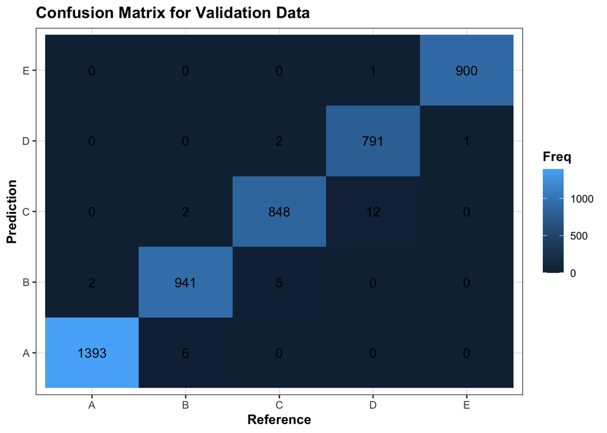

```r
cm_plot <- ggplot(cm_df, aes(Reference, Prediction, fill=Freq)) +
  geom_tile() +
  geom_text(aes(label=Freq)) +
  scale_fill_gradient() +
  theme_bw() +
  ggtitle("Confusion Matrix for Validation Data") +
  theme(title = element_text(face="bold"))

print(cm_plot)
```

```r
cm_validation <- cm
Accuracy_validation <- cm$overall["Accuracy"]
ErrorRate <- 1-Accuracy_validation
print(cm_validation)
```

```
## Confusion Matrix and Statistics
##
##           Reference
## Prediction    A    B    C    D    E
##          A 1393    6    0    0    0
##          B    2  941    5    0    0
##          C    0    2  848   12    0
##          D    0    0    2  791    1
##          E    0    0    0    1  900
##
## Overall Statistics
##
##                Accuracy : 0.9937
##                  95% CI : (0.991, 0.9957)
##     No Information Rate : 0.2845
##     P-Value [Acc > NIR] : < 2.2e-16
##
##                   Kappa : 0.992
##
##  Mcnemar's Test P-Value : NA
##
## Statistics by Class:
##
##                      Class: A Class: B Class: C Class: D Class: E
## Sensitivity            0.9986   0.9916   0.9918   0.9838   0.9989
## Specificity            0.9983   0.9982   0.9965   0.9993   0.9998
## Pos Pred Value         0.9957   0.9926   0.9838   0.9962   0.9989
## Neg Pred Value         0.9994   0.9980   0.9983   0.9968   0.9998
## Prevalence             0.2845   0.1935   0.1743   0.1639   0.1837
## Detection Rate         0.2841   0.1919   0.1729   0.1613   0.1835
## Detection Prevalence   0.2853   0.1933   0.1758   0.1619   0.1837
## Balanced Accuracy      0.9984   0.9949   0.9942   0.9915   0.9993
```

```r
paste0("The accuracy rate for the validation set is ", Accuracy_validation, ".")
```

```
## [1] "The accuracy rate for the validation set is 0.993678629690049."
```

```r
paste0("The Out-of-Sample error rate is ", ErrorRate, ".")
```

```
## [1] "The Out-of-Sample error rate is 0.00632137030995106."
```

#The model hits a very high accuracy rate on the validation set as well.

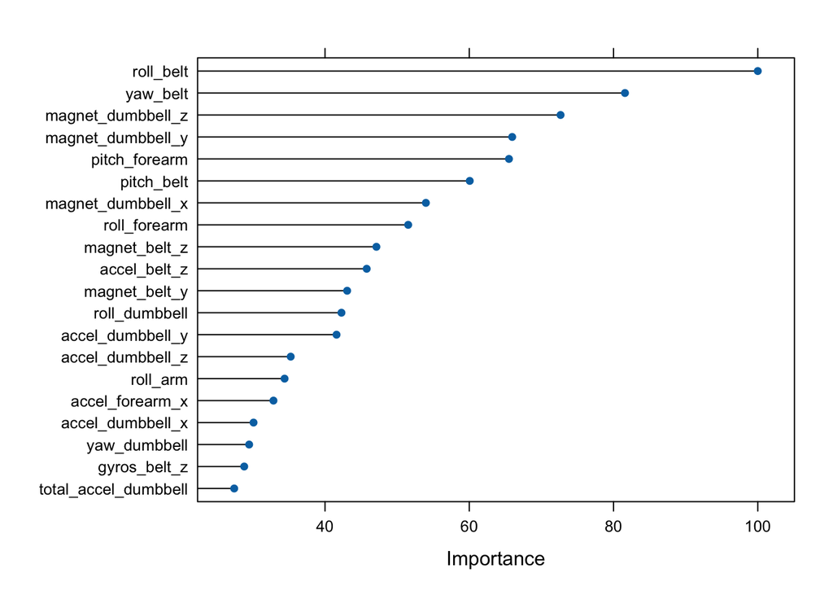

```r
varImp_obj <- varImp(model_RF)
VarImpPlot <- plot(varImp_obj, top=20)
print(VarImpPlot)
```

```r
pdp_rollbelt <- partial(
  object = model_RF,
  pred.var = "roll_belt",
  train = train,
  type = "classification"
)
```

```r
p1 <- autoplot(pdp_rollbelt) +
  theme_minimal()
  ylab("Classe Probability")
```

```
## $y
## [1] "Classe Probability"
##
## attr(,"class")
## [1] "labels"
```

```r
pdp_pitchforearm <- partial(
  object = model_RF,
  pred.var = "pitch_forearm",
  train = train
)
```

```r
p2 <- autoplot(pdp_pitchforearm) +
  theme_minimal() +
  ylab("Classe Probability")
```

```r
pdp_yawbelt <- partial(
  object = model_RF,
  pred.var = "yaw_belt",
  train = train
)
```

```r
p3 <- autoplot(pdp_yawbelt) +
  theme_minimal() +
  ylab("Classe Probability")
```

[figure not shown]

```r
pdp_all <- p1 / (p2 | p3)
pdp_all <- pdp_all + plot_annotation(
  title = "Partial Dependence Plots for Top 3 Variables",
  theme = theme(plot.title = element_text(size=16, face="bold")))
pdp_all
```

```r
pred_test <- predict(model_RF, newdata=testing)
pred_test
```

```
##  [1] B A B A A E D B A A B C B A E E A B B B
## Levels: A B C D E
```